# Biodiversity of macrozoobenthic communities - 2

2017-11-28

## Biodiversity, taxonomic distinctness & graphical community analyses

This is a continuation of the community analyses started in part 1. Includes the selection of more sophisticated descriptive community analyses of biodiversity, again applied on the 3 separate datasets.

Some setup, to make this notebook stand-alone.

Define the working subdirectories.

```r
data.dir <- "data"    # input data files
functions.dir <- "R"  # functions & scripts
save.dir <- "output"  # clean data, output from models & more complex calculations
figures.dir <- "figs" # plots & figures
```

Import functions.

```r
source(file.path(functions.dir, "alpha_diversity.R"))
```

Import the necessary libraries.

```r
library(vegan)
library(tidyverse)
library(viridis)
```

Organize some commonly-used ggplot2 modifications into a more convenient (and less repetitive) format.

```r
## ggplot settings & things that I keep reusing
# ggplot_theme <- list(
#   theme_bw(),
#   theme(element_text(family = "Times"))
# )
## always use black-and-white theme
theme_set(theme_bw())
## helper to adjust ggplot text size & avoid repetitions
text_size <- function(text.x = NULL,
                      text.y = NULL,
                      title.x = NULL,
                      title.y = NULL,
                      legend.text = NULL,
                      legend.title = NULL,
                      strip.x = NULL,
                      strip.y = NULL) {
  theme(axis.text.x = element_text(size = text.x),
        axis.text.y = element_text(size = text.y),
        axis.title.x = element_text(size = title.x),
        axis.title.y = element_text(size = title.y),
        legend.text = element_text(size = legend.text),
        legend.title = element_text(size = legend.title),
        strip.text.x = element_text(size = strip.x),
        strip.text.y = element_text(size = strip.y)
        )
  }
```

#### Macrozoobenthic communities in the sandy sediments of Burgas Bay (2013-2014)

Import the zoobenthic abundance & biomass data - as an exception, from the cleaned & saved datasets, to avoid (most of) the cleaning steps.

Convert columns to the proper type, arrange the datasets by station, etc.

Remove all species not present in the datasets (= all-0 columns).

##### Alpha diversity indices

All of the following can be calculated using package vegan. + species richness S  
+ Shannon-Wiener biodiversity index H’ (log2) - quantifies the probability that any two species drawn from the community are different - measure of entropy, NOT diversity! Therefore doesn’t behave linearly. Actually measures the level of disorder in the system (more disorder = more diversity).  
+ Pielou evenness index J’ - - level of dominance in the community. Close to 1 - the abundance is more evenly distrbuted among the species; close to 0 - one or several species largely dominate in abundance over the others.  
+ effective Shannon diversity (= corresponding Hill number) - to allow a meaningful comparison of diversity, not of entropy. Effective numbers impose a linear transformation on Shannon diversity - represent the number of equally abundant species necessary to produce the observed value of diversity. Range from 1 to S, where a value of S would indicate all species are present and in equal abundances.

```r
## uses custom function for convenience - has to be imported first!
alpha.div.sand <- zoo.abnd.sand %>%
  select(-c(station:replicate)) %>%
  alpha_diversity()

## add the metadata columns (row order is not changed, so possible)
(alpha.div.sand <- bind_cols(zoo.abnd.sand %>% select(station:replicate),
                            alpha.div.sand)
)
```

[output not shown]

Summarize these diversity indices by station & year.

```r
## might be a good place to eventually learn how to use the functions from package sjPlot for printing pretty (and easy!) tables...
alpha.div.sand %>%
  group_by(station, year) %>%
  summarise(h_mean = mean(shannon_h), h_sd = sd(shannon_h),
            j_mean = mean(evenness_j), j_sd = sd(evenness_j),
            h_eff_mean = mean(h_effective), h_eff_sd = sd(h_effective)
            )
```

[output not shown]

2. Species accumulation curves - see how species are added when the number of samples (sites) increases. Usually used to see if the sampling effort is adequate & captures most of the diversity in the study area.

```r
sac.sand <- specaccum(select(zoo.abnd.sand, -c(station:replicate)))

plot(sac.sand,
     xlab = "Samples", ylab = "Cumulative species richness",
     ci.type = "polygon", ci.col = "light blue")
```

[output not shown]

About 10 samples seem to be enough to capture most of the biodiversity in the study area (in terms of species richness) - this is where the curve starts to smooth out (slope < 1). In my dataset, there are 9 samples/station - could be considered enough.  
NB IF this method is applied correctly, since the samples are not independent but in fact represent replicates at each station.

##### Species pool

The species pool is the total extrapolated number of species in the study area (various estimates used here). Used to estimate the number of **unobserved species**. The functions assume that the number of unobserved species is related to he number of rare species (= seen only once or twice).

```r
## this function is based on incidences in sample sites - presence/absence data; gives a single estimate for a collection of sample sites
specpool(select(zoo.abnd.sand, -c(station:replicate)),
         pool = zoo.abnd.sand$station,
         smallsample = TRUE)

## this function is quantitative - based on abundances on single sample site
estimateR(select(zoo.abnd.sand, -c(station:replicate)))
```

[output not shown]

Now let’s do it for the whole dataset.

```r
specpool(select(zoo.abnd.sand, -c(station:replicate)),
         smallsample = TRUE)
```

[output not shown]

Looks good: based on the most severe estimate (second-order jacknife), the dataset captures about 77 % of the species pool, and based on the most forgiving one (bootstrap) - about 91 %.

##### Taxonomic distance & diversity

Simple diversity measures do not distinguish between species. However, in the real world, species relationships (phylogenetic, taxonomic, functional..) matter, and could carry important ecologcial information.  
For these analyses, a master species list for the whole study area is needed. For the Black Sea, it was compiled using the Catalogue of Black Sea Fauna & its 2 updates, as well as other, more recent inventories (full references & details in Materials & methods).

```r
## NB imported with row names on purpose, otherwise later some vegan functions fail!
master.tax.list <- read.csv(file = file.path(data.dir, "td_zoo_taxonomy.csv"), header = TRUE, row.names = 1)
```

Now we’ll calculate the **taxonomic distance** for the dataset.

```r
summary(tax.distinctness.sand)
```

```
           Delta  Delta*  Delta+ sd(Delta+) z(Delta+)  Pr(>|z|)
1        68.9636 78.6493 87.1330     1.8598    0.4309 0.6665638
2        59.0935 71.9195 87.0065     1.9514    0.3458 0.7294946
3        66.3850 76.2118 84.1537     1.7772   -1.2255 0.2203850
4        57.8318 71.4672 86.0039     2.1696   -0.1511 0.8799209
5        65.2703 76.4840 86.3878     1.6335    0.0343 0.9726051
6        65.6794 77.3323 86.9785     1.8175    0.3559 0.7219368
7        61.7144 73.1716 85.9300     1.8598   -0.2160 0.8289819
8        54.4000 69.7227 86.8170     2.0011    0.2425 0.8083687
9        67.2667 77.4521 86.8281     2.0011    0.2481 0.8040795
10       61.6227 74.8318 86.6135     2.5420    0.1109 0.9117141
11       69.1137 76.9792 84.8200     1.7021   -0.8881 0.3744680
12       69.6512 79.0576 86.5948     1.9044    0.1382 0.8900973
13       78.6338 85.5233 87.3839     1.7388    0.6051 0.5451011
14       74.5909 83.3657 87.4196     1.7388    0.6257 0.5315324
```

[output cut: 43 more lines]

Construct the 95% confidence funnels for the taxonomic distance using the master species list. Actually, these are probably meant to be 95% tolerance intervals (limits containing at least 95% of all observations), but it’s a very big can of other statistical worms that I just can’t bear to open; they wrote “confidence intervals” so that stays.  
Thankfully, I can do this once for all three datasets - the simulation takes a lot of time and computational power.

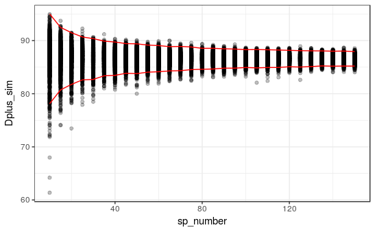

Now plot the real, observed values of D-plus in the sand dataset, and add these confidence limits.

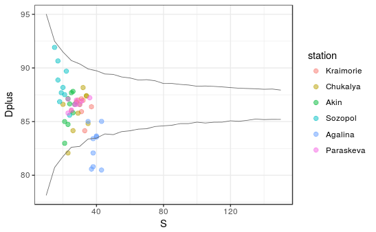

Summarize the taxonomic distinctness indices by station.

```r
# aggregate taxonomic distinctness indices by station and year
tax.dist.table$stations <- reorder.factor(tax.dist.table$stations,
                                            new.order = stations.sand)
```

[output not shown]

##### Graphical analyses

```r
div.profiles.sand <- diversity_profiles(select(zoo.abnd.sand, -c(station:replicate)))

## plot them, too
```

It’s possible to calculate **weighted diversity profiles** by including a measure of similarity between species - for instance, taxonomic distance between them. This approach allows for a lot more meaningful ecological and biodiversity comparisons (Leinster & Cobbold, 2012).